# Final Project “Top 10 Causes of Death in the USA, 1999-2017”

Uliana Plotnikova

December 11, 2019

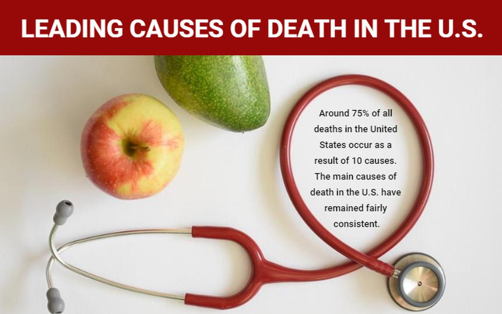

Picture

# Introduction

In the past 100 years, Americans have gained approximately 25 more years of expectancy. These gains were due to significant declines in mortality that occurred as acute infectious diseases were replaced by chronic diseases as the predominant cause of morbidity and mortality. However, 2017 was the third year in a row where U.S. life expectancy fell, a rare event that has only occurred three times in the last century. One other three-year decline occurred in 1916, 1917 and 1918, when the worst flu pandemic in modern history eliminated nearly 7% of the US population. My initial intention was to analyze mortality only in New York state, then I decided to explore death causes in the entire United States. Since I work in health care environment I took advantage to analyse Leading Causes of Death in United States data in order to expand my knowledge and skills.

This dataset is taken from Data.gov presents the age-adjusted death rates for the 10 leading causes of death in the United States beginning in 1999. Data are based on information from all resident death certificates filed in the 50 states and the District of Columbia using demographic and medical characteristics. Age-adjusted death rates (per 100,000 population) are based on the 2000 U.S. standard population.Age-adjusted death rates are useful when comparing different populations because they remove the potential bias that can occur when the populations being compared have different age structures.

# Data Acquisition

```r
#Load necessary libraries
suppressWarnings({library(mongolite)})
suppressWarnings({library(ggthemes)})
suppressWarnings({library(gganimate)})
suppressWarnings({library(magick)})
suppressWarnings({library(gapminder)})
suppressWarnings({library(ggplot2)})
suppressWarnings({library(dplyr)})
suppressWarnings({library(lubridate)})
suppressWarnings({library(stringr)})
suppressWarnings({library(plotrix)})
suppressWarnings({library(reshape)})
suppressWarnings({library(knitr)})
suppressWarnings({library(tidyverse)})
suppressWarnings({library(kableExtra)})
suppressWarnings({library(usmap)})
```

```r
url <- "https://raw.githubusercontent.com/uplotnik/FinalProject607/master/USA%20leading%20Causes%20of%20death.csv"
datasetx <- read.csv(url)
head(datasetx)
```

```
##   Year                                      X113.Cause.Name
## 1 2017 Accidents (unintentional injuries) (V01-X59,Y85-Y86)
## 2 2017 Accidents (unintentional injuries) (V01-X59,Y85-Y86)
## 3 2017 Accidents (unintentional injuries) (V01-X59,Y85-Y86)
## 4 2017 Accidents (unintentional injuries) (V01-X59,Y85-Y86)
## 5 2017 Accidents (unintentional injuries) (V01-X59,Y85-Y86)
## 6 2017 Accidents (unintentional injuries) (V01-X59,Y85-Y86)
##               Cause.Name         State Deaths Age.adjusted.Death.Rate
## 1 Unintentional injuries United States 169936                    49.4
## 2 Unintentional injuries       Alabama   2703                    53.8
## 3 Unintentional injuries        Alaska    436                    63.7
## 4 Unintentional injuries       Arizona   4184                    56.2
## 5 Unintentional injuries      Arkansas   1625                    51.8
## 6 Unintentional injuries    California  13840                    33.2
```

## Read Data from MongoDB

```r
mongo_db <- mongo(collection = "Causes of Deaths in USA")
mongo_db$insert(datasetx)
```

```
## List of 5
##  $ nInserted  : num 10868
##  $ nMatched   : num 0
##  $ nRemoved   : num 0
##  $ nUpserted  : num 0
##  $ writeErrors: list()
```

```r
head(mongo_db$find())
```

```
##   Year                                      X113_Cause_Name
## 1 2017 Accidents (unintentional injuries) (V01-X59,Y85-Y86)
## 2 2017 Accidents (unintentional injuries) (V01-X59,Y85-Y86)
## 3 2017 Accidents (unintentional injuries) (V01-X59,Y85-Y86)
## 4 2017 Accidents (unintentional injuries) (V01-X59,Y85-Y86)
## 5 2017 Accidents (unintentional injuries) (V01-X59,Y85-Y86)
## 6 2017 Accidents (unintentional injuries) (V01-X59,Y85-Y86)
##               Cause_Name         State Deaths Age_adjusted_Death_Rate Cause
## 1 Unintentional injuries United States 169936                    49.4  <NA>
## 2 Unintentional injuries       Alabama   2703                    53.8  <NA>
## 3 Unintentional injuries        Alaska    436                    63.7  <NA>
## 4 Unintentional injuries       Arizona   4184                    56.2  <NA>
## 5 Unintentional injuries      Arkansas   1625                    51.8  <NA>
## 6 Unintentional injuries    California  13840                    33.2  <NA>
```

## Data Preparation

```r
datasetx <- read.csv(url,header = TRUE, na.strings=".")
datasetx<-distinct(datasetx)
datasetx<-datasetx[,-2]
kable(head(datasetx))
```

| Year | Cause.Name | State | Deaths | Age.adjusted.Death.Rate |
| --- | --- | --- | --- | --- |
| 2017 | Unintentional injuries | United States | 169936 | 49.4 |
| 2017 | Unintentional injuries | Alabama | 2703 | 53.8 |
| 2017 | Unintentional injuries | Alaska | 436 | 63.7 |
| 2017 | Unintentional injuries | Arizona | 4184 | 56.2 |
| 2017 | Unintentional injuries | Arkansas | 1625 | 51.8 |
| 2017 | Unintentional injuries | California | 13840 | 33.2 |

# Data Analysis

## Exploratory Analysis

```r
dim(datasetx)
```

```
## [1] 10868     5
```

```r
str(datasetx)
```

```
## 'data.frame':    10868 obs. of  5 variables:
##  $ Year                   : int  2017 2017 2017 2017 2017 2017 2017 2017 2017 2017 ...
##  $ Cause.Name             : Factor w/ 11 levels "All causes","Alzheimer's disease",..: 11 11 11 11 11 11 11 11 11 11 ...
##  $ State                  : Factor w/ 52 levels "Alabama","Alaska",..: 45 1 2 3 4 5 6 7 8 9 ...
##  $ Deaths                 : int  169936 2703 436 4184 1625 13840 3037 2078 608 427 ...
##  $ Age.adjusted.Death.Rate: num  49.4 53.8 63.7 56.2 51.8 33.2 53.6 53.2 61.9 61 ...
```

```r
summary(datasetx)
```

```
##       Year                    Cause.Name          State          Deaths
##  Min.   :1999   All causes         : 988   Alabama   : 209   Min.   :     21
##  1st Qu.:2003   Alzheimer's disease: 988   Alaska    : 209   1st Qu.:    612
##  Median :2008   Cancer             : 988   Arizona   : 209   Median :   1718
##  Mean   :2008   CLRD               : 988   Arkansas  : 209   Mean   :  15460
##  3rd Qu.:2013   Diabetes           : 988   California: 209   3rd Qu.:   5756
##  Max.   :2017   Heart disease      : 988   Colorado  : 209   Max.   :2813503
##                 (Other)            :4940   (Other)   :9614
##  Age.adjusted.Death.Rate
##  Min.   :   2.6
##  1st Qu.:  19.2
##  Median :  35.9
##  Mean   : 127.6
##  3rd Qu.: 151.7
##  Max.   :1087.3
##
```

# Total Number of Death by Year

### Filter data by All Causes in entire United States

```r
USA<-filter(datasetx, datasetx$State == "United States")
all_causes_usa<-filter(USA, USA$Cause.Name == "All causes")
kable(head((all_causes_usa),10))
```

| Year | Cause.Name | State | Deaths | Age.adjusted.Death.Rate |
| --- | --- | --- | --- | --- |
| 2017 | All causes | United States | 2813503 | 731.9 |
| 2016 | All causes | United States | 2744248 | 728.8 |
| 2015 | All causes | United States | 2712630 | 733.1 |
| 2014 | All causes | United States | 2626418 | 724.6 |
| 2013 | All causes | United States | 2596993 | 731.9 |
| 2012 | All causes | United States | 2543279 | 732.8 |
| 2011 | All causes | United States | 2515458 | 741.3 |
| 2010 | All causes | United States | 2468435 | 747.0 |
| 2009 | All causes | United States | 2437163 | 749.6 |
| 2008 | All causes | United States | 2471984 | 774.9 |

### Add Death Proportion of each year

```r
yearlydeath<- USA %>%
    group_by(Year) %>%
    summarise(avg_Deaths = mean(Deaths),
              min_Deaths = min(Deaths),
              max_Deaths = max(Deaths),
              total_deaths= sum(Deaths))%>%
         mutate(total_deaths_prop = prop.table(total_deaths))%>%
  arrange(desc(Year))
kable(head(yearlydeath,5))
```

| Year | avg_Deaths | min_Deaths | max_Deaths | total_deaths | total_deaths_prop |
| --- | --- | --- | --- | --- | --- |
| 2017 | 445003.1 | 47173 | 2813503 | 4895034 | 0.0582679 |
| 2016 | 434397.0 | 44965 | 2744248 | 4778367 | 0.0568791 |
| 2015 | 429604.3 | 44193 | 2712630 | 4725647 | 0.0562516 |
| 2014 | 414984.2 | 42826 | 2626418 | 4564826 | 0.0543372 |
| 2013 | 409754.9 | 41149 | 2596993 | 4507304 | 0.0536525 |

### Find Ave, Min, Max and Total Death 1999-2017

```r
total<-yearlydeath %>%
  summarise(avg_deaths_1999_2017 = mean(avg_Deaths),
            min_deaths_1999_2017 = min(min_Deaths),
              max_deaths_1999_2017 = max(max_Deaths),
            total_deaths_1999_2017= sum(total_deaths))
kable(total)
```

| avg_deaths_1999_2017 | min_deaths_1999_2017 | max_deaths_1999_2017 | total_deaths_1999_2017 |
| --- | --- | --- | --- |
| 401957.7 | 29199 | 2813503 | 84009152 |

### When was the Max and Min number of Deaths?

```r
max<-all_causes_usa %>% slice(which.max(Deaths))
kable(max)
```

| Year | Cause.Name | State | Deaths | Age.adjusted.Death.Rate |
| --- | --- | --- | --- | --- |
| 2017 | All causes | United States | 2813503 | 731.9 |

```r
min<-all_causes_usa%>% slice(which.min(Deaths))
kable(min)
```

| Year | Cause.Name | State | Deaths | Age.adjusted.Death.Rate |
| --- | --- | --- | --- | --- |
| 1999 | All causes | United States | 2391399 | 875.6 |

The maximum Number of deaths: 2,813,503 is registered in 2017 and the Minimum Number: 2,391,399 is registered in 1999.

### Visualization

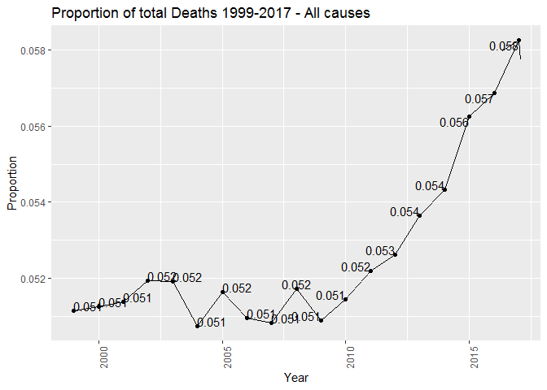

```r
mortality<-ggplot(data=yearlydeath, aes(x=Year, y=total_deaths_prop, group=10)) +
  geom_line(arrow = arrow())+
  geom_point()+
  geom_text(aes(label = round(total_deaths_prop,3)),
            vjust = "inward", hjust = "inward",
            show.legend = FALSE)+
  theme(axis.text.x = element_text(angle = 90, hjust = 1))+
  labs( x="Year", y="Proportion")+ggtitle("Proportion of total Deaths 1999-2017 - All causes ")
mortality
```

### Death Rate change between years

```r
pct_change <- all_causes_usa %>%
   group_by(Cause.Name) %>%
  mutate(pct_change = (Deaths/lead(Deaths)-1) * 100)
data_wide1<- pct_change %>%
  select(1:4,6)
data_wide2<-spread(data_wide1, State, Deaths)
kable(head(data_wide2))
```

| Year | Cause.Name | pct_change | United States |
| --- | --- | --- | --- |
| 1999 | All causes | NA | 2391399 |
| 2000 | All causes | 0.4997911 | 2403351 |
| 2001 | All causes | 0.5439905 | 2416425 |
| 2002 | All causes | 1.1157805 | 2443387 |
| 2003 | All causes | 0.2005822 | 2448288 |
| 2004 | All causes | -2.0697320 | 2397615 |

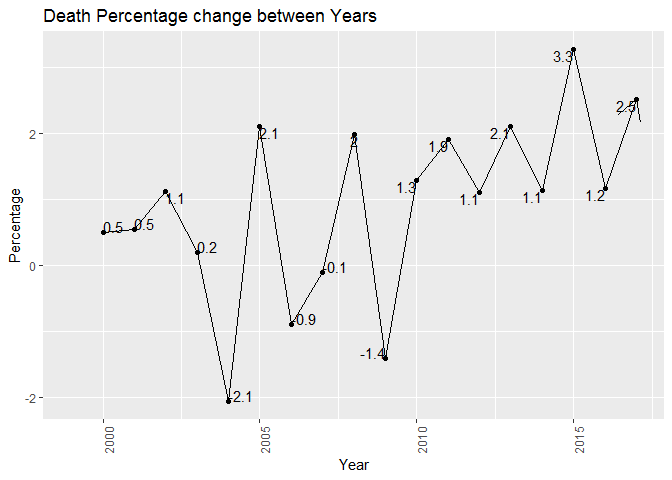

```r
perc_change<-ggplot(data=data_wide2, aes(x=Year, y=pct_change, group=10)) +
  geom_line(arrow = arrow())+
  geom_point()+
  geom_text(aes(label = round(pct_change, 1)),
            vjust = "inward", hjust = "inward",
            show.legend = FALSE)+
  theme(axis.text.x = element_text(angle = 90, hjust = 1))+
  labs( x="Year", y="Percentage")+ggtitle("Death Percentage change between Years ")
perc_change
```

The number of death are going up! But the population of US has been growing.In order to see more accurate data, we need to check age-adjusted death rate for the total population.

## Age Adjusted Death Rate

AGE-ADJUSTED DEATH RATE is a death rate that controls for the effects of differences in population age distributions. When comparing across geographic areas, some method of age- adjusting is typically used to control for the influence that different population age distributions might have on health event rates.

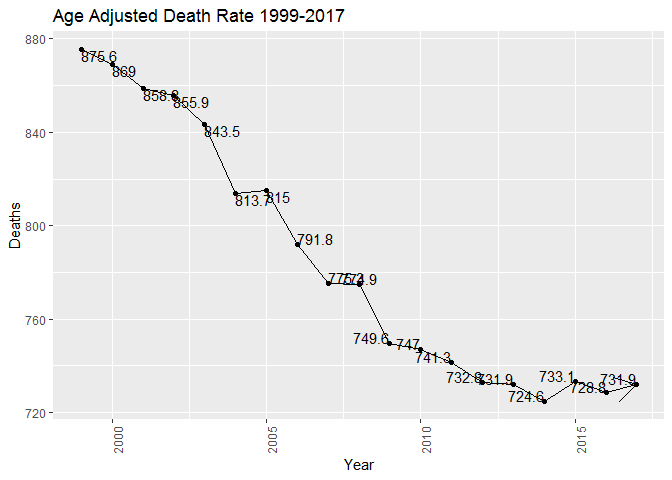

```r
g3<-ggplot(data=all_causes_usa, aes(x=Year, y=Age.adjusted.Death.Rate, group=10)) +
  geom_line(arrow = arrow())+
  geom_point()+
  geom_text(aes(label = round(Age.adjusted.Death.Rate, 1)),
            vjust = "inward", hjust = "inward",
            show.legend = FALSE)+
  theme(axis.text.x = element_text(angle = 90, hjust = 1))+
  labs( x="Year", y="Deaths")+ggtitle("Age Adjusted Death Rate 1999-2017")
g3
```

Age Adjusted Death rate decreased on 16% from 1999 to 2017.

## Mortality vs Age Adjusted Death Rate

```r
states<-datasetx[!grepl('United States',datasetx$State),]
all_causes_states<-filter(states, states$Cause.Name == "All causes")
```

```r
p <- ggplot(
  all_causes_states,
  aes(x = Age.adjusted.Death.Rate, y=Deaths,  colour = State)
  ) +
  geom_point(show.legend = FALSE, alpha = 0.7) +
  scale_color_viridis_d() +
  scale_size(range = c(2, 12)) +
  scale_x_log10() +
  labs(x = "Age.adjusted.Death.Rate", y = "Deaths")
```

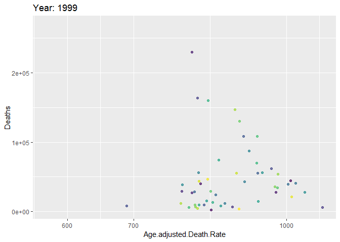

```r
p + transition_time(Year)+
  labs(title = "Year: {frame_time}")+
    shadow_mark(alpha = 0.3, size = 0.5)
```

# Leading Causes of Death in USA 1999-2017

```r
dataset1<-USA[!grepl('All causes',USA$Cause.Name),]
```

```r
dataset_wide<-dataset1%>%select(-State, -Age.adjusted.Death.Rate)
dataset_wide1<-spread(dataset_wide, Year, Deaths)
kable(head(dataset_wide1))%>%
    kable_styling(bootstrap_options = "striped", full_width = F)%>%
    row_spec(5, bold = T, color = "white", background = "orange")%>%
  row_spec(2, bold = T, color = "white", background = "orange")
```

| Cause.Name | 1999 | 2000 | 2001 | 2002 | 2003 | 2004 | 2005 | 2006 | 2007 | 2008 | 2009 | 2010 | 2011 | 2012 | 2013 | 2014 | 2015 | 2016 | 2017 |
| --- | --- | --- | --- | --- | --- | --- | --- | --- | --- | --- | --- | --- | --- | --- | --- | --- | --- | --- | --- |
| Alzheimer’s disease | 44536 | 49558 | 53852 | 58866 | 63457 | 65965 | 71599 | 72432 | 74632 | 82435 | 79003 | 83494 | 84974 | 83637 | 84767 | 93541 | 110561 | 116103 | 121404 |
| Cancer | 549838 | 553091 | 553768 | 557271 | 556902 | 553888 | 559312 | 559888 | 562875 | 565469 | 567628 | 574743 | 576691 | 582623 | 584881 | 591700 | 595930 | 598038 | 599108 |
| CLRD | 124181 | 122009 | 123013 | 124816 | 126382 | 121987 | 130933 | 124583 | 127924 | 141090 | 137353 | 138080 | 142943 | 143489 | 149205 | 147101 | 155041 | 154596 | 160201 |
| Diabetes | 68399 | 69301 | 71372 | 73249 | 74219 | 73138 | 75119 | 72449 | 71382 | 70553 | 68705 | 69071 | 73831 | 73932 | 75578 | 76488 | 79535 | 80058 | 83564 |
| Heart disease | 725192 | 710760 | 700142 | 696947 | 685089 | 652486 | 652091 | 631636 | 616067 | 616828 | 599413 | 597689 | 596577 | 599711 | 611105 | 614348 | 633842 | 635260 | 647457 |
| Influenza and pneumonia | 63730 | 65313 | 62034 | 65681 | 65163 | 59664 | 63001 | 56326 | 52717 | 56284 | 53692 | 50097 | 53826 | 50636 | 56979 | 55227 | 57062 | 51537 | 55672 |

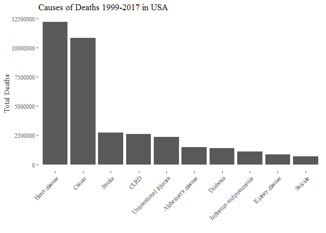

```r
ggplot(aes(x =  reorder(Cause.Name,-Deaths), y = Deaths), data = dataset1) +
  geom_bar(stat = 'identity') +
  ylab('Total Deaths') +
  xlab('') +
  ggtitle('Causes of Deaths 1999-2017 in USA') +
  theme_tufte() +
  theme(axis.text.x = element_text(angle = 45, hjust = 1))
```

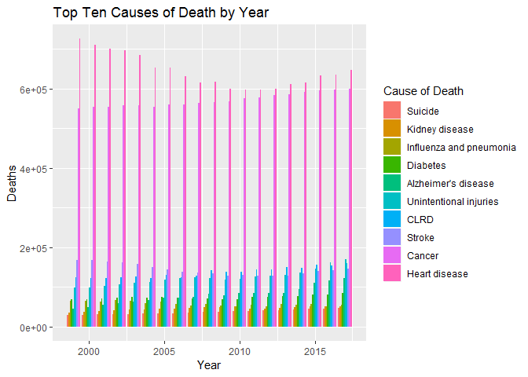

```r
  ggplot(dataset1, aes(x= Year,y=Deaths)) +
  geom_bar(aes(fill = reorder(Cause.Name,Deaths)), position ="dodge",
  stat = "identity") +
  ggtitle("Top Ten Causes of Death by Year") +
  ylab(label = "Deaths" )+
  scale_fill_discrete(name = "Cause of Death")
```

```r
pie<-dataset1
pie1<-aggregate(pie$Deaths, by=list(Cause=pie$Cause), FUN=sum)
pie2<-pie1%>% mutate(Perc=x/sum(x))
```

```r
 slices <- c(1494816, 10843644, 2594927, 1399943, 12222640,1094641, 858613,2726523,697016,2347820)
 lbls <- c("Alzheimer's disease ", "Cancer", "CLRD", "Diabetes", "Heart disease"," Influenza and pneumonia  ", "Kidney disease", "Stroke", "Suicide", "Unintentional injuries")
 pct <- round(slices/sum(slices)*100)
 lbls <- paste(lbls, pct) # add percents to labels
 lbls <- paste(lbls,"%",sep="") # ad % to labels
 pie3D(slices,labels = lbls,explode = 0.3, col=rainbow(length(lbls)),
    main="Causes of Mortality 1999-2017")
```

[figure not shown]

```r
p <- ggplot(
  dataset1,
  aes(Year, Deaths, group = Cause.Name, color = factor(Cause.Name))
  ) +
  geom_line() +
  scale_color_viridis_d() +
  labs(x = "Year", y = "Deaths") +
  theme(legend.position = "top")
```

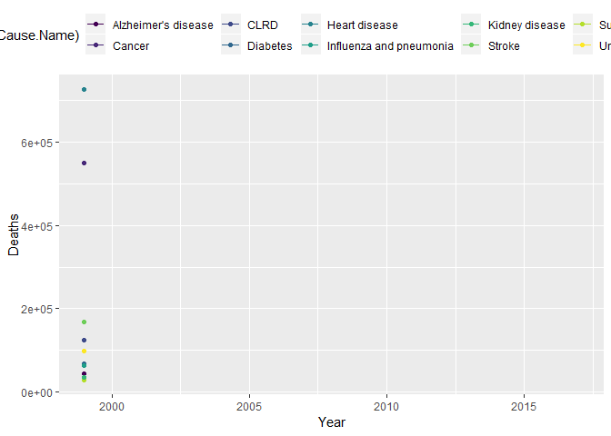

```r
p + geom_point(aes(group = seq_along(Year))) +
  transition_reveal(Year)
```

# Mortality by State

## Filter by all states and all causes

```r
states<-datasetx[!grepl('United States',datasetx$State),]
```

```r
all_causes_states<-filter(states, states$Cause.Name == "All causes")
head(all_causes_states)%>%arrange(desc(Deaths))
```

```
##   Year Cause.Name      State Deaths Age.adjusted.Death.Rate
## 1 2017 All causes California 268189                   618.7
## 2 2017 All causes    Arizona  57758                   678.5
## 3 2017 All causes    Alabama  53238                   917.7
## 4 2017 All causes   Colorado  38063                   663.4
## 5 2017 All causes   Arkansas  32588                   900.1
## 6 2017 All causes     Alaska   4411                   708.8
```

## Age Adjusted Death Rate for each state 1999-2017

```r
dataset_wide_state<-all_causes_states%>%select(-Cause.Name, -Deaths)
dataset_wide_state1<-spread(dataset_wide_state, Year, Age.adjusted.Death.Rate)
kable(head(dataset_wide_state1))%>%
    kable_styling(bootstrap_options = "striped", full_width = F)
```

| State | 1999 | 2000 | 2001 | 2002 | 2003 | 2004 | 2005 | 2006 | 2007 | 2008 | 2009 | 2010 | 2011 | 2012 | 2013 | 2014 | 2015 | 2016 | 2017 |
| --- | --- | --- | --- | --- | --- | --- | --- | --- | --- | --- | --- | --- | --- | --- | --- | --- | --- | --- | --- |
| Alabama | 1009.3 | 1004.8 | 1002.1 | 1013.4 | 1020.2 | 998.3 | 1001.3 | 979.5 | 957.2 | 959.7 | 940.2 | 939.7 | 933.6 | 926.7 | 925.2 | 909.1 | 924.5 | 920.4 | 917.7 |
| Alaska | 838.9 | 869.1 | 831.3 | 802.4 | 843.5 | 756.7 | 762.3 | 787.6 | 780.6 | 761.3 | 763.8 | 771.5 | 747.8 | 731.4 | 724.4 | 736.8 | 747.4 | 745.6 | 708.8 |
| Arizona | 818.4 | 810.4 | 795.9 | 811.2 | 798.4 | 771.1 | 786.7 | 767.1 | 731.0 | 714.5 | 693.8 | 693.1 | 688.9 | 682.9 | 674.2 | 661.7 | 671.8 | 675.8 | 678.5 |
| Arkansas | 975.3 | 977.1 | 955.4 | 975.2 | 948.2 | 927.4 | 931.5 | 909.5 | 906.2 | 927.3 | 896.4 | 892.7 | 895.3 | 897.5 | 893.8 | 883.7 | 901.8 | 893.2 | 900.1 |
| California | 802.3 | 787.9 | 783.2 | 770.0 | 768.4 | 734.3 | 730.7 | 718.2 | 691.7 | 677.9 | 655.5 | 646.7 | 641.3 | 630.4 | 630.1 | 605.7 | 621.6 | 616.9 | 618.7 |
| Colorado | 801.8 | 792.1 | 796.1 | 804.4 | 792.0 | 738.5 | 752.1 | 720.9 | 708.0 | 715.8 | 689.7 | 682.7 | 677.8 | 665.6 | 655.4 | 664.4 | 665.0 | 669.5 | 663.4 |

## Avg, Min, Max Age Adjusted Death Rate for each State

```r
statedeath<- all_causes_states %>%
    group_by(State) %>%
    summarise(Avg_Rate = mean(Age.adjusted.Death.Rate),
              Min_Rate = min(Age.adjusted.Death.Rate),
              Max_Rate = max(Age.adjusted.Death.Rate)) %>%

  arrange(State)
kable(head(statedeath,5))
```

| State | Avg_Rate | Min_Rate | Max_Rate |
| --- | --- | --- | --- |
| Alabama | 962.2579 | 909.1 | 1020.2 |
| Alaska | 774.2737 | 708.8 | 869.1 |
| Arizona | 732.9158 | 661.7 | 818.4 |
| Arkansas | 920.4000 | 883.7 | 977.1 |
| California | 691.1316 | 605.7 | 802.3 |

## When was the higest/lowest death rate?

```r
maxrate<-all_causes_states %>% slice(which.max(Age.adjusted.Death.Rate))
kable(maxrate)
```

| Year | Cause.Name | State | Deaths | Age.adjusted.Death.Rate |
| --- | --- | --- | --- | --- |
| 1999 | All causes | District of Columbia | 6076 | 1087.3 |

```r
minrate<-all_causes_states %>% slice(which.min(Age.adjusted.Death.Rate))
kable(minrate)
```

| Year | Cause.Name | State | Deaths | Age.adjusted.Death.Rate |
| --- | --- | --- | --- | --- |
| 2016 | All causes | Hawaii | 10913 | 572 |

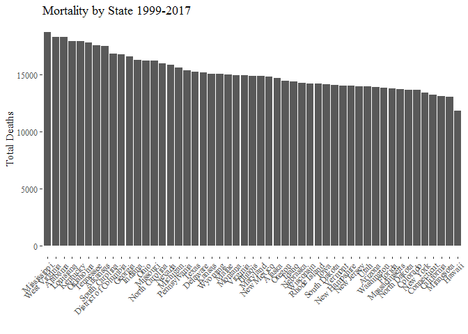

```r
ggplot(aes(x =  reorder(State,-Age.adjusted.Death.Rate), y = Age.adjusted.Death.Rate), data = all_causes_states) +
  geom_bar(stat = 'identity') +
  ylab('Total Deaths') +
  xlab('') +
  ggtitle('Mortality by State 1999-2017') +
  theme_tufte() +
  theme(axis.text.x = element_text(angle = 45, hjust = 1))
```